# BMIN503/EPID600 Project: Examining the association between fertility treatment and live birth

### Results

Now that data cleaning is complete, I will examine the baseline characteristics of the participants by fertility treatment. This is the table 1.

```r
fertility_data %>%
  select(c(STRATA, Marital_status_f, Annual_Household_Income_f, Health_Insur_f, Fertility_Insur_f,
            Race_f,  Highest_Degree_f, BMI_f, BMI_m, Age_f, Age_m, employment_f, F3FERTDX, tx_cat)) %>%
    mutate(Annual_Household_Income_f = droplevels(Annual_Household_Income_f)) %>%
  tbl_summary(by = tx_cat,
              label = list(STRATA ~ "Location of enrollment", Marital_status_f ~ "Relationship status", Annual_Household_Income_f ~ "Annual household income", Health_Insur_f ~ "Health insurance", Fertility_Insur_f ~ "Fertility insurance", Race_f ~ "Race and ethnicity", Highest_Degree_f ~ "Education", BMI_f ~ "BMI (female partner)", BMI_m ~ "BMI (male partner)", Age_f ~ "Age (female partner)", Age_m ~ "Age (male partner)", employment_f ~ "Employment status", F3FERTDX ~ "Infertility diagnosis"), missing_text = "Missing") %>%
  italicize_labels() %>%
  add_p()
```

| **Characteristic** | **No fertility treatment**, N = 536<sup>1</sup> | **IVF**, N = 412<sup>1</sup> | **IUI**, N = 855<sup>1</sup> | **OI**, N = 361<sup>1</sup> | **p-value**<sup>2</sup> |
| --- | --- | --- | --- | --- | --- |
| Location of enrollment |  |  |  |  | <0.001 |
| IVF | 38 (7.1%) | 287 (70%) | 23 (2.7%) | 5 (1.4%) |  |
| Non-IVF, non-study site | 174 (32%) | 11 (2.7%) | 68 (8.0%) | 28 (7.8%) |  |
| Non-IVF, study site | 324 (60%) | 114 (28%) | 764 (89%) | 328 (91%) |  |
| Relationship status |  |  |  |  |  |
| Do not wish to provide | 0 (0%) | 0 (0%) | 2 (0.2%) | 0 (0%) |  |
| Living as married/living with partner | 39 (7.3%) | 16 (3.9%) | 25 (2.9%) | 26 (7.2%) |  |
| Married | 495 (92%) | 395 (96%) | 825 (96%) | 334 (93%) |  |
| Single | 2 (0.4%) | 1 (0.2%) | 3 (0.4%) | 1 (0.3%) |  |
| Annual household income |  |  |  |  | <0.001 |
| < $40,000 | 113 (22%) | 26 (6.7%) | 98 (12%) | 54 (16%) |  |
| >= $100,000 | 81 (16%) | 160 (41%) | 208 (26%) | 46 (14%) |  |
| $40,000 - <$75,000 | 211 (42%) | 109 (28%) | 313 (39%) | 152 (45%) |  |
| $75,000 - <$100,000 | 98 (19%) | 94 (24%) | 193 (24%) | 85 (25%) |  |
| Missing | 33 | 23 | 43 | 24 |  |
| Health insurance |  |  |  |  |  |
| Do not wish to provide | 6 (1.1%) | 6 (1.5%) | 9 (1.1%) | 1 (0.3%) |  |
| No | 24 (4.5%) | 7 (1.7%) | 14 (1.6%) | 10 (2.8%) |  |
| Yes | 506 (94%) | 399 (97%) | 832 (97%) | 350 (97%) |  |
| Fertility insurance |  |  |  |  | <0.001 |
| Do not wish to provide | 168 (33%) | 41 (10%) | 223 (27%) | 87 (25%) |  |
| No | 225 (44%) | 201 (50%) | 348 (42%) | 158 (45%) |  |
| Yes | 113 (22%) | 157 (39%) | 261 (31%) | 105 (30%) |  |
| Missing | 30 | 13 | 23 | 11 |  |
| Race and ethnicity |  |  |  |  |  |
| Asian | 28 (5.2%) | 27 (6.6%) | 46 (5.4%) | 20 (5.5%) |  |
| Black or African American | 12 (2.2%) | 4 (1.0%) | 18 (2.1%) | 1 (0.3%) |  |
| Do not wish to provide | 0 (0%) | 1 (0.2%) | 8 (0.9%) | 3 (0.8%) |  |
| Hispanic/Latino | 35 (6.5%) | 20 (4.9%) | 31 (3.6%) | 22 (6.1%) |  |
| Other race/ethnic groups | 27 (5.0%) | 9 (2.2%) | 30 (3.5%) | 17 (4.7%) |  |
| White | 434 (81%) | 351 (85%) | 722 (84%) | 298 (83%) |  |
| Education |  |  |  |  | <0.001 |
| Bachelor's degree | 191 (36%) | 171 (42%) | 312 (36%) | 127 (35%) |  |
| Did not wish to provide | 8 (1.5%) | 6 (1.5%) | 12 (1.4%) | 4 (1.1%) |  |
| High school or less | 67 (12%) | 25 (6.1%) | 90 (11%) | 57 (16%) |  |
| Master's degree or higher | 62 (12%) | 123 (30%) | 153 (18%) | 55 (15%) |  |
| Some college | 208 (39%) | 87 (21%) | 288 (34%) | 118 (33%) |  |
| BMI (female partner) | 27 (22, 35) | 25 (22, 30) | 26 (22, 33) | 28 (23, 36) | <0.001 |
| Missing | 3 | 1 | 4 | 0 |  |
| BMI (male partner) | 29 (25, 33) | 29 (25, 32) | 28 (25, 33) | 28 (25, 33) | 0.3 |
| Missing | 1 | 1 | 2 | 0 |  |
| Age (female partner) | 30.0 (27.0, 34.0) | 32.0 (29.0, 35.0) | 30.0 (27.0, 34.0) | 29.0 (26.0, 33.0) | <0.001 |
| Age (male partner) | 32.0 (28.0, 36.0) | 33.0 (30.0, 37.2) | 32.0 (29.0, 36.0) | 31.0 (27.0, 34.0) | <0.001 |
| Employment status |  |  |  |  | 0.007 |
| x1 | 98 (19%) | 61 (16%) | 111 (14%) | 60 (17%) |  |
| x2 | 74 (15%) | 59 (16%) | 144 (18%) | 64 (18%) |  |
| x3 | 315 (62%) | 256 (68%) | 523 (65%) | 217 (61%) |  |
| x4 | 21 (4.1%) | 1 (0.3%) | 26 (3.2%) | 12 (3.4%) |  |
| Missing | 28 | 35 | 51 | 8 |  |
| Infertility diagnosis | 77 (22%) | 89 (40%) | 111 (19%) | 32 (12%) | <0.001 |
| Missing | 184 | 189 | 282 | 102 |  |

<sup>1</sup> n (%); Median (IQR)  
<sup>2</sup> Pearson's Chi-squared test; Kruskal-Wallis rank sum test

```r
fertility_data %>%
    group_by(tx_cat) %>%
    summarise(count = n()) %>%
    mutate(prop = count/sum(count))
```

```
## # A tibble: 4 × 3
##   tx_cat                 count  prop
##   <fct>                  <int> <dbl>
## 1 No fertility treatment   536 0.248
## 2 IVF                      412 0.190
## 3 IUI                      855 0.395
## 4 OI                       361 0.167
```

Before we start running regression models, I want to view the exposure and outcome of interest using descriptive plots.

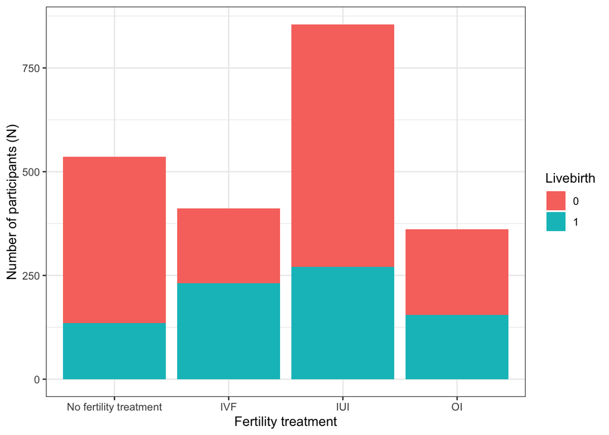

```r
ggplot(data = fertility_data, aes(x = tx_cat, fill = live_birth)) +
  geom_bar() +
  xlab("Fertility treatment") + ylab("Number of participants (N)") +
  labs(fill = "Livebirth") + #How do I make the labels in the legend?
  theme_bw()
```

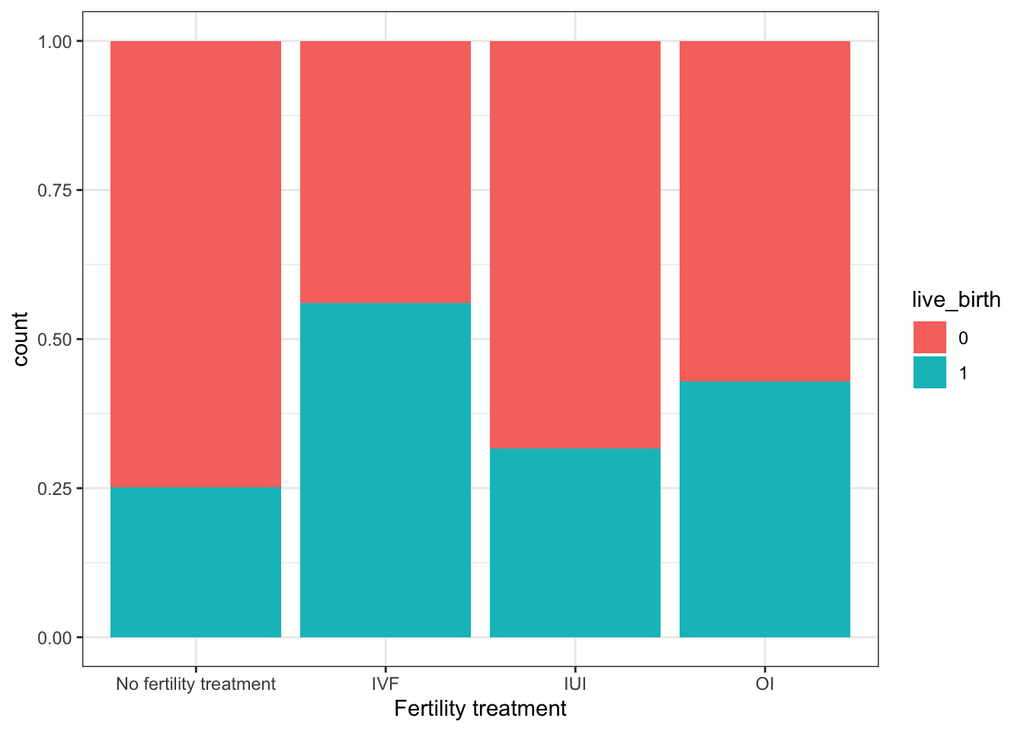

```r
ggplot(data = fertility_data, aes(x = tx_cat, fill = live_birth)) +
  geom_bar(position = "fill") +
  xlab("Fertility treatment") +
  theme_bw()
```

Based on the plots, it looks like there is a difference in livebirth by fertility treatment. First, I will run chi-square to see if there is a difference, and then I will run a logistic regression, presenting both the unadjusted and adjusted results.

```r
chisq.test(table(fertility_data$live_birth, fertility_data$tx_cat))
```

```
##
##  Pearson's Chi-squared test
##
## data:  table(fertility_data$live_birth, fertility_data$tx_cat)
## X-squared = 112.49, df = 3, p-value < 2.2e-16
```

```r
unadjusted <- glm(live_birth ~ tx_cat, data = fertility_data, family = "binomial") %>%
  tbl_regression(exponentiate = TRUE)
adjusted <- glm(live_birth ~ tx_cat + Age_f + Age_m + BMI_f + BMI_m + F3FERTDX, data = fertility_data, family = "binomial") %>%
  tbl_regression(exponentiate = TRUE)

tbl_merge(
    tbls = list(unadjusted, adjusted),
    tab_spanner = c("**Unadjusted**", "**Adjusted**")
    ##Any advice on how I can tell R to not show the covariates and add a footnote instead?
  )
```

| **Characteristic** | **Unadjusted** **OR**<sup>1</sup> | **Unadjusted** **95% CI**<sup>1</sup> | **Unadjusted** **p-value** | **Adjusted** **OR**<sup>1</sup> | **Adjusted** **95% CI**<sup>1</sup> | **Adjusted** **p-value** |
| --- | --- | --- | --- | --- | --- | --- |
| tx_cat |  |  |  |  |  |  |
| No fertility treatment | — | — |  | — | — |  |
| IVF | 3.79 | 2.88, 5.00 | <0.001 | 3.62 | 2.50, 5.27 | <0.001 |
| IUI | 1.38 | 1.08, 1.76 | 0.009 | 1.46 | 1.08, 1.98 | 0.015 |
| OI | 2.23 | 1.68, 2.98 | <0.001 | 2.49 | 1.76, 3.54 | <0.001 |
| Age_f |  |  |  | 0.99 | 0.95, 1.02 | 0.5 |
| Age_m |  |  |  | 0.96 | 0.93, 0.99 | 0.007 |
| BMI_f |  |  |  | 0.98 | 0.97, 1.00 | 0.035 |
| BMI_m |  |  |  | 1.00 | 0.98, 1.02 | 0.8 |
| F3FERTDX |  |  |  |  |  |  |
| No |  |  |  | — | — |  |
| Yes |  |  |  | 0.93 | 0.70, 1.23 | 0.6 |

<sup>1</sup> OR = Odds Ratio, CI = Confidence Interval

```r
fertility.rf <- randomForest(live_birth ~ tx_cat + Age_f + Age_m, data = fertility_data,
                             ntree = 100, importance = TRUE)
fertility.rf
```

```
##
## Call:
##  randomForest(formula = live_birth ~ tx_cat + Age_f + Age_m, data = fertility_data,      ntree = 100, importance = TRUE)
##                Type of random forest: classification
##                      Number of trees: 100
## No. of variables tried at each split: 1
##
##         OOB estimate of  error rate: 35.07%
## Confusion matrix:
##      0   1 class.error
## 0 1193 179   0.1304665
## 1  580 212   0.7323232
```

```r
fertility.rf.pred <- predict(fertility.rf, fertility_data, type = "prob")
rf.pred.livebirth <- fertility.rf.pred[ , 2]

#K-Fold Cross Validation
N = nrow(fertility_data)
K = 10
set.seed(1234)
s = sample(1:K, size = N, replace = T)
pred.outputs.rf <- vector(mode = "numeric", length = N)
obs.outputs <- vector(mode = "numeric", length = N)
offset <- 0
for(i in 1:K){
    train <- filter(fertility_data, s != i)
    test <- filter(fertility_data, s == i)
    obs.outputs[1:length(s[s == i]) + offset] <- test$live_birth

    #RF train/test
    rf <- randomForest(live_birth ~ tx_cat + Age_f + Age_m, data = fertility_data, ntree = 50)
    rf.pred.curr <- predict(rf, newdata = test, type = "prob")
    pred.outputs.rf[1:length(s[s == i]) + offset] <- rf.pred.curr[ , 2]

    offset <- offset + length(s[s == i])
}

roc(obs.outputs, pred.outputs.rf, ci = TRUE)
```

```
##
## Call:
## roc.default(response = obs.outputs, predictor = pred.outputs.rf,     ci = TRUE)
##
## Data: pred.outputs.rf in 1372 controls (obs.outputs 1) < 792 cases (obs.outputs 2).
## Area under the curve: 0.7401
## 95% CI: 0.719-0.7612 (DeLong)
```

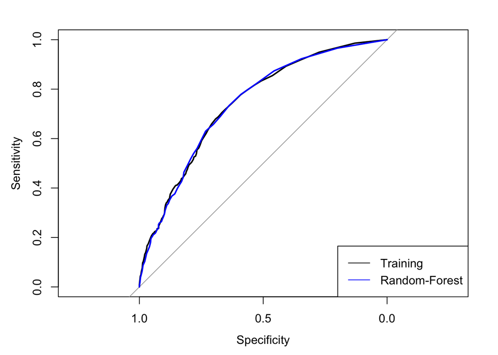

```r
plot.roc(fertility_data$live_birth, rf.pred.livebirth)
plot.roc(obs.outputs, pred.outputs.rf, ci = TRUE, col = "blue", add = TRUE)
legend("bottomright", legend = c("Training", "Random-Forest"), col = c("black", "blue"), lwd = 1)
```

As an exploratory analysis, we will examine time to pregnancy that resulted in a livebirth by fertility treatment. Fist, we will visualize the relationship to see if there are differences by using a Kaplan-Meier plot.

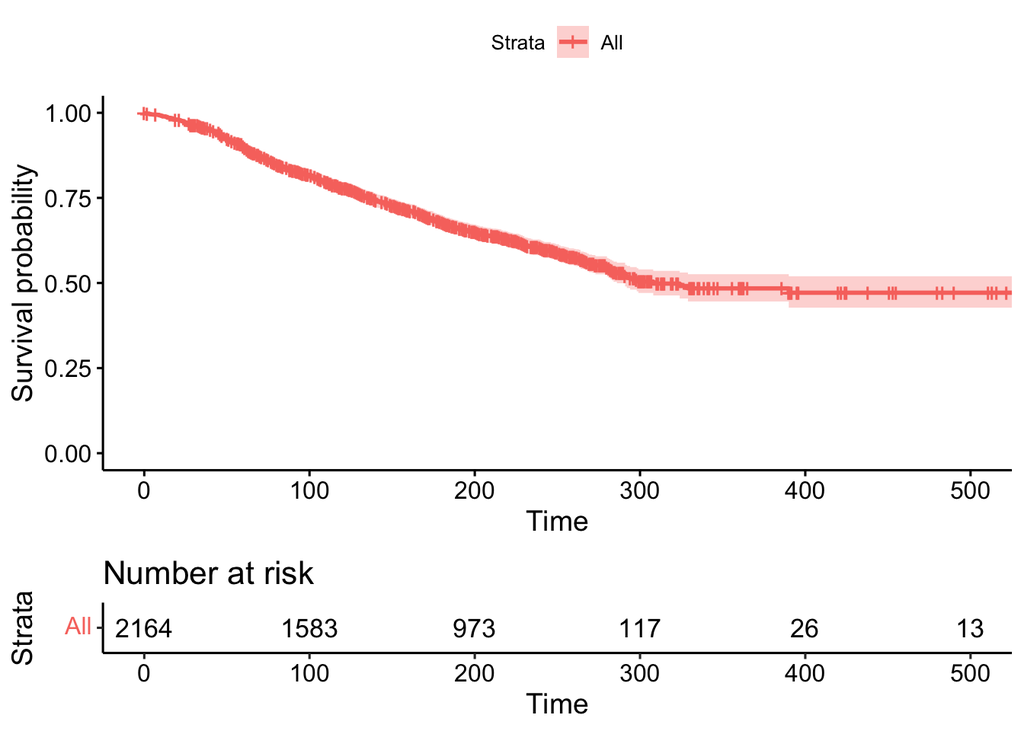

```r
fertility_data$live_birth_num <- as.numeric(fertility_data$live_birth)
fit <- survfit(Surv(time, live_birth_num) ~ 1,
               data = fertility_data)
# Visualize with survminer
ggsurvplot(fit, data = fertility_data, risk.table = TRUE)
```

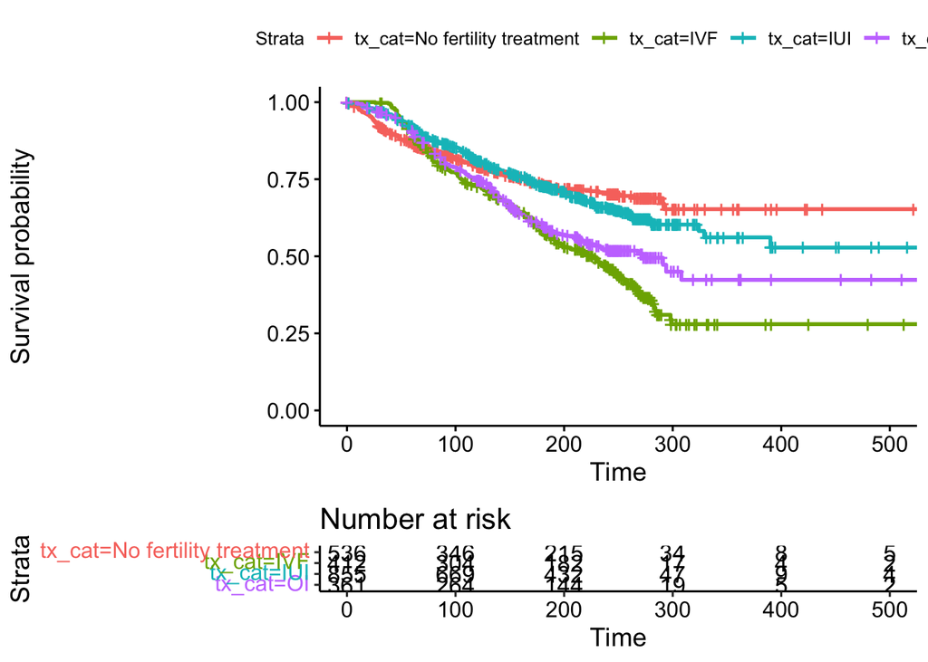

```r
tx_fit <- survfit(Surv(time, live_birth_num) ~ tx_cat,
               data = fertility_data)
# Visualize with survminer
ggsurvplot(tx_fit, data = fertility_data, risk.table = TRUE) ##How do I make it so the risk table isn't squished?
```

Based on the plot above, it looks like there may be an issue with the proportional hazards assumption. This assumption can be tested statistically and graphically.

```r
surv_diff <- survdiff(Surv(time, live_birth_num) ~ tx_cat, data = fertility_data)
surv_diff
```

```
## Call:
## survdiff(formula = Surv(time, live_birth_num) ~ tx_cat, data = fertility_data)
##
##                                 N Observed Expected (O-E)^2/E (O-E)^2/V
## tx_cat=No fertility treatment 536      135      178     10.21     13.21
## tx_cat=IVF                    412      231      154     38.38     47.78
## tx_cat=IUI                    855      271      333     11.64     20.17
## tx_cat=OI                     361      155      127      6.17      7.37
##
##  Chisq= 66.6  on 3 degrees of freedom, p= 2e-14
```

```r
res.cox <- coxph(Surv(time, live_birth) ~ tx_cat, fertility_data, id = COUPLEID)
res.cox
```

```
## Call:
## coxph(formula = Surv(time, live_birth) ~ tx_cat, data = fertility_data,
##     id = COUPLEID)
##
##
## 1:2            coef exp(coef) se(coef) robust se     z        p
##   tx_catIVF 0.68031   1.97448  0.10836   0.10965 6.204 5.49e-10
##   tx_catIUI 0.06734   1.06966  0.10538   0.10932 0.616    0.538
##   tx_catOI  0.47419   1.60671  0.11776   0.12129 3.910 9.24e-05
##
##  States:  1= (s0), 2= 1
##
## Likelihood ratio test=62.78  on 3 df, p=1.493e-13
## n= 2164, number of events= 792
```

```r
test.ph <- cox.zph(res.cox)
test.ph
```

```
##        chisq df       p
## tx_cat  53.3  3 1.6e-11
## GLOBAL  53.3  3 1.6e-11
```

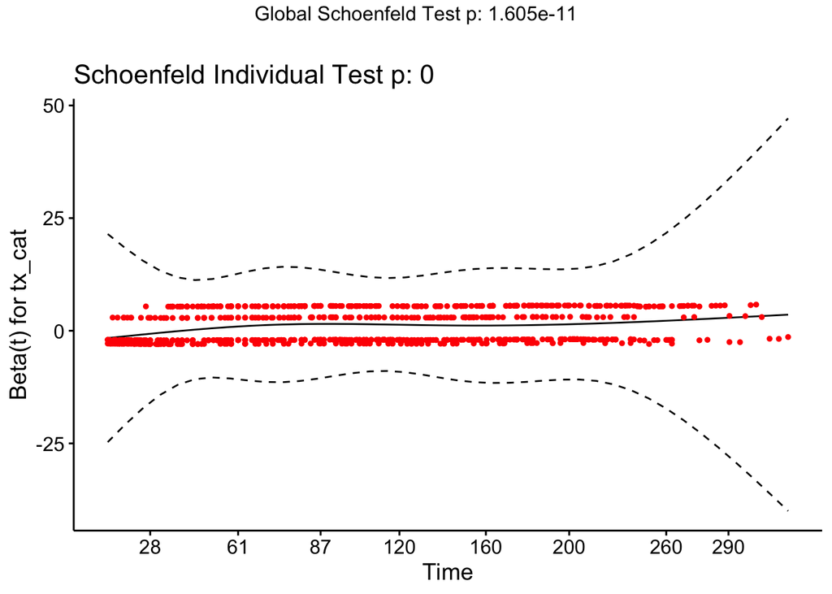

```r
ggcoxzph(test.ph)
```